# Lab_7

Kim Youngrae

2016년 11월 21일

# Contents

- Equal variance assumption
- Unequal variance assumption
- Holdout procedure (LOOCV)

먼저 사용할 자료를 불러온다. 오늘 사용할 자료는 책 Example 11.8의 자료이다. 이는 연어의 나이테 직경의 자료이며, 이는 연어의 출생지역과 관련이 있다고 알려져 있다. 우리는 이 나이테 직경을 이용해 어디서 태어난 연어인지 알아보려고 한다.

```r
setwd("/Users/kyr0302/Desktop/Lab_7")
data<-read.table("T11-2.dat")
colnames(data)<-c("region","gender","Freshwater","Marine")
head(data)
```

```
##   region gender Freshwater Marine
## 1      1      2        108    368
## 2      1      1        131    355
## 3      1      1        105    469
## 4      1      2         86    506
## 5      1      1         99    402
## 6      1      2         87    423
```

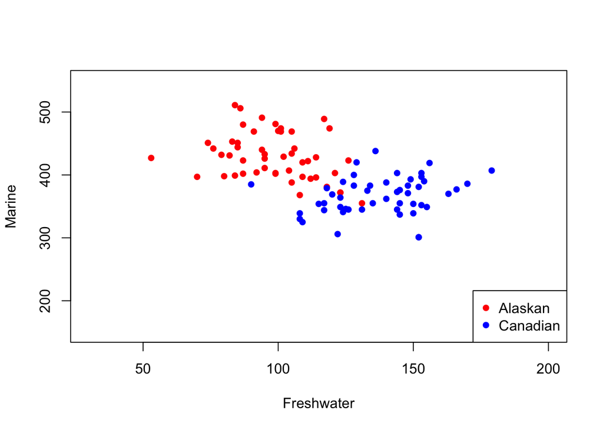

```r
plot(data[data$region==1,3:4],col="red",type="p",xlim=c(30,200),ylim=c(150,550),pch=16)
points(data[data$region==2,3:4],col="blue",pch=16)
legend("bottomright",c("Alaskan","Canadian"), col=c("Red","Blue"), text.col = "black",
       pch=c(16,16,16), merge = TRUE)
```

# Equal variance assumption

먼저 Equal variance를 가정한 채로, 분류를 해보려 한다. 두 개의 Class를 가지는 상황이므로, 이때 우리의 Classifier는 다음과 같다.

새로운 자료 $x_0$에 대해,

$(\bar{x}_1-\bar{x}_2)^TS_{pooled}^{-1}x_0 - \frac{1}{2}(\bar{x}_1-\bar{x}_2)^TS_{pooled}^{-1}(\bar{x}_1+\bar{x}_2)\geq \log[(\frac{c(1|2)}{c(2|1)}(\frac{p_2}{p_1})]$

이면, $x_0$를 Group 1으로, 그렇지 않으면 Group 2로 분류한다.

$c(1|2)=c(2|1), p_1=p_2$를 가정한다.

```r
S_pooled<-(n1-1)/(n-2)*S1+(n2-1)/(n-2)*S2
S_pooled.inv<-solve(S_pooled)
A<-(x1bar-x2bar)%*%S_pooled.inv
B<-(x1bar-x2bar)%*%S_pooled.inv%*%(x1bar+x2bar)/2
c1.2=1; c2.1=1; p1=0.5; p2=0.5    ## Cost, p
threshold<-log(c1.2/c2.1*p2/p1)
class<-rep(0,nrow(data))
```

여기서 $c(1|2),c(2|1)$와 $p_1, p_2$ 는 설정할 수 있다.

```r
for(i in 1:nrow(data)){
  if(A%*%t(data[i,3:4])-B>threshold) class[i]<-1
  else class[i]<-2;
}
```

if 안에 들어있는 조건식이 위에서 본 Classifier이고, 이를 만족하면 1, 아니면 2로 분류하기로 하였다.

이를 바탕으로, 실제 True region과 우리의 분류결과를 비교하면 다음과 같다.

```r
table(data[,1],class)
```

```
##    class
##      1  2
##   1 44  6
##   2  1 49
```

# Unequal variance assumption

이번엔 Equal variance를 가정하지 않은, Quadratic 방법을 사용해보려고 한다. 이번에 우리가 사용할 Classifier는 다음과 같다.

새로운 자료 $x_0$에 대해,

$-\frac{1}{2}x_0^T(S_1^{-1}-S_2^{-1})x_0+(\bar{x}_1^TS_1^{-1}-\bar{x}_2^TS_2^{-1})x_0-k \geq \log[(\frac{c(1|2)}{c(2|1)}(\frac{p_2}{p_1})]$

이면, $x_0$를 Group 1으로, 그렇지 않으면 Group 2로 분류한다.

여기서 $k=\frac{1}{2}log(\frac{\det{\Sigma_1}}{\det{\Sigma_2}})+\frac{1}{2}(\mu_1^T\Sigma_1^{-1}\mu_1-\mu_2^T\Sigma_2^{-1}\mu_2)$로 결정하고, True값을 모르니, 추정량들로 대체한다.

역시 $c(1|2)=c(2|1), p_1=p_2$를 가정한다. 이 Classifier를 이용해 분류해보면 다음과 같다.

```r
S1.inv<-solve(S1);
S2.inv<-solve(S2);
A<-x1bar%*%S1.inv-x2bar%*%S2.inv;
B<-S1.inv-S2.inv;
k<-(log(det(S1)/det(S2))+x1bar%*%S1.inv%*%x1bar-x2bar%*%S2.inv%*%x2bar)/2;
c1.2=1; c2.1=1; p1=0.5; p2=0.5;
threshold<-log(c1.2/c2.1*p2/p1);
class<-rep(0,nrow(data));
```

```r
for(i in 1:nrow(data)){
  x0<-as.numeric(data[i,3:4])
  if(-x0%*%B%*%x0/2+A%*%x0-k>threshold) class[i]<-1
  else class[i]<-2;
}
table(data[,1],class)
```

```
##    class
##      1  2
##   1 45  5
##   2  2 48
```

위와 같은 결과를 얻을 수 있다.

# Holdout procedure (LOOCV)

이번엔, Holdout procedure를 생각해보려고 한다. 이 방법은 분류해야할 대상 $x_0$를 제외한 나머지 자료들로 Classifier 를 만든 다음, 그 Classifier로 $x_0$가 어떤 Group에 속할지 결정하는 방법이다. Classifier 를 만들 때 우리는 자료의 Sample covariance의 Inverse가 필요한데, 한개의 자료만 뺄 때는 Sample covariance의 inverse 를 쉽게 구할 수 있다.

### Sherman-Morrison-Woodbery Lemma

$(A+uv^{T})^{-1}=A^{-1}-{A^{-1}uv^{T}A^{-1} \over 1+v^{T}A^{-1}u}$

위의 S-M-W Lemma는 Unequal variance 가정일때, 필요할 것이고, Eqaul variance 가정에선 $S_{pooled}$의 역행렬을 쉽게 구할 수 있어야 한다. 이를 위해 미리 계산해둔 $S_{H,pooled}^{-1}$ 를 이용하도록 한다.

$x_H \in \pi_k$ 일 때,

$S_{H,pooled}^{-1} = \frac{n-3}{n-2} (S_{pooled}^{-1} + \frac{c_k}{1 - c_k(x_H - \bar{x}_k)^TS_{pooled}^{-1}(x_H-\bar{x}_k)}* S_{pooled}^{-1}(x_H-\bar{x}_k)(x_H-\bar{x}_k)^TS_{pooled}^{-1})$

이때 $c_k = \frac{n_k}{(n_k-1)(n-2)}$ 이다.